# Modeling the diffusion of a new product

## Frank Bass (1926-2006)

“F. Bass, A New Product Growth for Model Consumer Durables, Management Science, Vol. 15 (January 1969)”

> Perhaps the first thing to notice. . . is the title. It contains a typo. The correct title should be “A New Product Growth Model for Consumer Durables” I suppose that I was so excited about having the paper accepted for publication that I failed to carefully proofread the galley proofs. (Frank Bass, 2004)

One of 10 papers in the selection Top 10 Most Influential Papers published in the 50-year history of Management Science (2004).

## Innovators and Imitators

The basic idea - there are two types of customers

Innovators:

- they buy the product using the information about the product, advertisement, etc.

Imitators:

- their decision is based on experience of other people, their ratings, etc.

## Model Parameters

- m = size of market
- p = coefficient of innovation
- q = coefficient of imitation
- N = cumulative adoptions so far
- n = adoptions predicted in current period

Liklihood of a new adoption at time $t$ is,

$$p+q\frac{N}{m}$$

We multiply this by the remainder of the market,

$$m-N$$

in order to get current year adoptions,

$$n=[p+q\frac{N}{m}][m-N]$$

## Model Estimation

When you multiply these terms out you get
$$n=pm+(q-p)N-\frac{q}{m}N^2$$

…which looks a lot like a problem we can estimate using OLS where,
$$n=a+bN+cN^2.$$
Since we know that market size occurs when $n=0$, we can solve for m using the quadradic equation, and the other variables follow.
$$m = \frac{-b\pm\sqrt{b^2-4ac}}{2c}$$
$$p = a/m \\
q=-mc$$

## Solution

Or… we can solve the parameter-free verion via the implied differential equation

$$\frac{dN(t)}{dt}=pm+(q-p)N(t-1)-\frac{q}{m}N(t-1)^2$$
which is:
$$N(t)=m\frac{1-e^{-(p+q)t}}{1+(\frac{q}{p})e^{-(p+q)t}}$$
and the corresponding function
$$N'(t)=n(t)=m\frac{(p+q)^2e^{-(p+q)t}}{p[1+\frac{q}{p}e^{-(p+q)t}]^2}$$

## Graphs

Given that m is just a constant, we can view graphs of the probability mass cumulative density using the following function

```r
graphs <- function(p,q,t.max) {
  t <-seq(from=0,to=t.max,by=0.01)
  Bass.f <- ((p+q)^2/p)*exp(-(p+q)*t)/(1+(q/p)*exp(-(p+q)*t))^2
  Bass.F <- (1-exp(-(p+q)*t))/(1+(q/p)*exp(-(p+q)*t))
  par(mfrow=c(1,2))
  plot(t, Bass.f, type="l")
  plot(t, Bass.F, type="l")
}
```

## Graphs cont’d

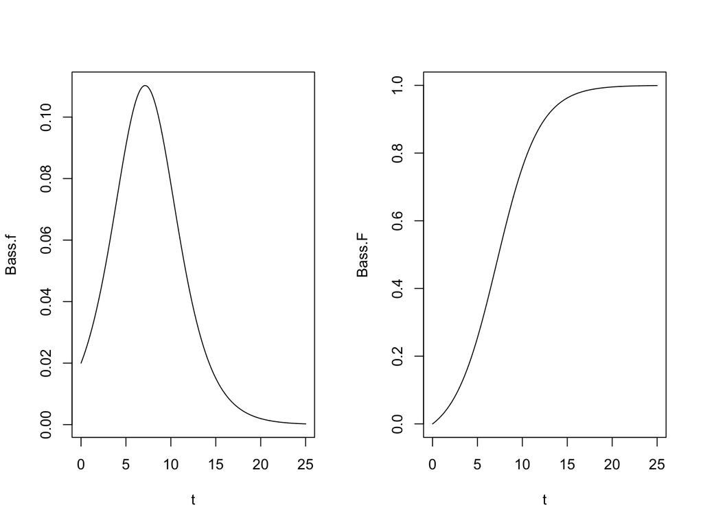

```r
graphs(0.02, 0.4, 25)
```

## Graphs cont’d

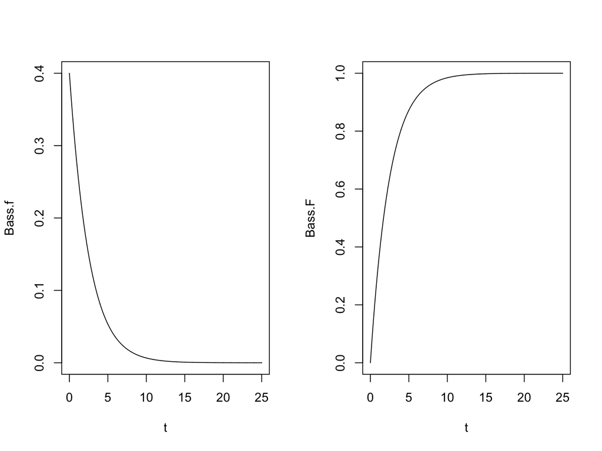

```r
graphs(0.4, 0.02, 25)
```

## Values of P and Q

…remember Rogers five factors?

- Relative advantage: the degree to which a product is better than the product it replaces
- Compatibility: the degree to which a product is consistent with existing values and experiences
- Complexity: the degree to which a product is difficult to understand and use
- Trialability: the degree to which a product may be experimented with on a limited basis
- Observability: the degree to which product usage and impact are visible to others

## Typical values

Parameters of the Bass Model in Several Product Categories

| Product | Innovation | Imitation |
| --- | --- | --- |
| B&W TV | 0.028 | 0.25 |
| Color TV | 0.005 | 0.84 |
| Air conditioners | 0.010 | 0.42 |
| Clothes dryers | 0.017 | 0.36 |
| Water softeners | 0.018 | 0.30 |
| Record players | 0.025 | 0.65 |
| Cellular telephones | 0.004 | 1.76 |
| Steam irons | 0.029 | 0.33 |
| Motels | 0.007 | 0.36 |
| McDonalds fast food | 0.018 | 0.54 |
| Hybrid corn | 0.039 | 1.01 |

A study by Sultan, Farley, and Lehmann in 1990 suggests an average value of 0.03 for p and an average value of 0.38 for q.

## Exercise

- Gather with a couple neighbors
- Use Roger’s 5 factors and the data given in the case to decide on p, q and m for E-books
- Create a spreadsheet that models sales over 25 years using the Bass model